# Success prediction for startups

## Samuel Felipe sanabria Posada

### GH1026419

https://github.com/samuelsanpo/machine_learning_success_prediction_for_startups

## Problem statement

### Business problem

In the venture capital investment business investors need to have at their disposal tools for decision making based on accurate information that allow them to correctly identify startups that have a high potential for exit, usually these decisions were made based on the experience or intiution of investors that although it is a great tool can lead to risks and losses.

In our company "Angel Investors Germany", specialized in investing in early stage startups, a tool is needed to improve the decision making process to provide investors with a guide to the opportunities they may have against new startups, so we propose the development of a machine learning model that predicts whether a startup will succeed or fail based on the different variables that will be analyzed in the model.

### Benefits for the company

This model will add great value to our organization as it will allow us to identify promising startups and avoid the risk of investing in startups that are likely to fail, stop making decisions based on intiution to make them based on quantifiable information and thus focus all efforts on projects with a higher probability of success.

### Data Collection

For our model we will be using publicly available information about the success or failure of startups obtained through the Kaggle platform, the dataset includes different features that we will see later, for future data collection if the model is successful we propose to collect data from APIs such as Crunchbase Pro or AngelList.

### Machine learning formulation

The problem will be approached as a classification problem, in this case binary, the goal is to predict whether a startup will be successful, meaning that it will achieve growth, exit its shares to the market, or be acquired by a larger company, or fail, meaning that this startup went bankrupt or is inactive. In this case, a supervised learning model is trained using the attributes as input features.

## Data exploration

```python
import pandas as pd
import seaborn as sns
import matplotlib.pyplot as plt
from IPython.display import display

# Loading dataset
df = pd.read_csv("startup_data.csv")

# Display first registers
df.head()
```

|  | Unnamed: 0 | state_code | latitude | longitude | zip_code | id | city | Unnamed: 6 | name | labels | ... | object_id | has_VC | has_angel | has_roundA | has_roundB | has_roundC | has_roundD | avg_participants | is_top500 | status |
| --- | --- | --- | --- | --- | --- | --- | --- | --- | --- | --- | --- | --- | --- | --- | --- | --- | --- | --- | --- | --- | --- |
| 0 | 1005 | CA | 42.358880 | -71.056820 | 92101 | c:6669 | San Diego | NaN | Bandsintown | 1 | ... | c:6669 | 0 | 1 | 0 | 0 | 0 | 0 | 1.0000 | 0 | acquired |
| 1 | 204 | CA | 37.238916 | -121.973718 | 95032 | c:16283 | Los Gatos | NaN | TriCipher | 1 | ... | c:16283 | 1 | 0 | 0 | 1 | 1 | 1 | 4.7500 | 1 | acquired |
| 2 | 1001 | CA | 32.901049 | -117.192656 | 92121 | c:65620 | San Diego | San Diego CA 92121 | Plixi | 1 | ... | c:65620 | 0 | 0 | 1 | 0 | 0 | 0 | 4.0000 | 1 | acquired |
| 3 | 738 | CA | 37.320309 | -122.050040 | 95014 | c:42668 | Cupertino | Cupertino CA 95014 | Solidcore Systems | 1 | ... | c:42668 | 0 | 0 | 0 | 1 | 1 | 1 | 3.3333 | 1 | acquired |
| 4 | 1002 | CA | 37.779281 | -122.419236 | 94105 | c:65806 | San Francisco | San Francisco CA 94105 | Inhale Digital | 0 | ... | c:65806 | 1 | 1 | 0 | 0 | 0 | 0 | 1.0000 | 1 | closed |

5 rows × 49 columns

```python
# Show dataset shape
print(f"Shape: {df.shape}")
```

```
Shape: (923, 49)
```

```python
# Check types
df.info()
```

```
<class 'pandas.core.frame.DataFrame'>
RangeIndex: 923 entries, 0 to 922
Data columns (total 49 columns):
 #   Column                    Non-Null Count  Dtype
---  ------                    --------------  -----
 0   Unnamed: 0                923 non-null    int64
 1   state_code                923 non-null    object
 2   latitude                  923 non-null    float64
 3   longitude                 923 non-null    float64
 4   zip_code                  923 non-null    object
 5   id                        923 non-null    object
 6   city                      923 non-null    object
 7   Unnamed: 6                430 non-null    object
 8   name                      923 non-null    object
 9   labels                    923 non-null    int64
```

[output cut: 41 more lines]

```python
# Checking for missing values
missingValues = df.isnull().sum()
print("\nMissing Values:\n", missingValues)
```

```
Missing Values:
 Unnamed: 0                    0
state_code                    0
latitude                      0
longitude                     0
zip_code                      0
id                            0
city                          0
Unnamed: 6                  493
name                          0
labels                        0
founded_at                    0
closed_at                   588
first_funding_at              0
last_funding_at               0
age_first_funding_year        0
age_last_funding_year         0
age_first_milestone_year    152
age_last_milestone_year     152
relationships                 0
funding_rounds                0
funding_total_usd             0
milestones                    0
state_code.1                  1
is_CA                         0
is_NY                         0
is_MA                         0
is_TX                         0
is_otherstate                 0
category_code                 0
is_software                   0
is_web                        0
is_mobile                     0
is_enterprise                 0
is_advertising                0
is_gamesvideo                 0
is_ecommerce                  0
is_biotech                    0
is_consulting                 0
is_othercategory              0
object_id                     0
has_VC                        0
has_angel                     0
has_roundA                    0
has_roundB                    0
has_roundC                    0
has_roundD                    0
avg_participants              0
is_top500                     0
status                        0
dtype: int64
```

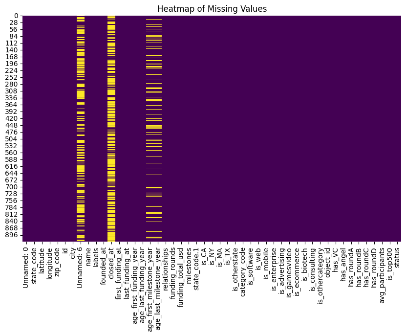

```python
# Heatmap of missing values
plt.figure(figsize=(10, 6))
sns.heatmap(df.isnull(), cbar=False, cmap="viridis", cbar_kws={'label': 'Missing Data'})
plt.title("Heatmap of Missing Values")
plt.show()
```

```python
# Display statistics for numerical columns
print("\nNumerical Statistics:\n")
numerical_summary = df.describe()
display(numerical_summary)
```

```
Numerical Statistics:
```

|  | Unnamed: 0 | latitude | longitude | labels | age_first_funding_year | age_last_funding_year | age_first_milestone_year | age_last_milestone_year | relationships | funding_rounds | ... | is_consulting | is_othercategory | has_VC | has_angel | has_roundA | has_roundB | has_roundC | has_roundD | avg_participants | is_top500 |
| --- | --- | --- | --- | --- | --- | --- | --- | --- | --- | --- | --- | --- | --- | --- | --- | --- | --- | --- | --- | --- | --- |
| count | 923.000000 | 923.000000 | 923.000000 | 923.000000 | 923.000000 | 923.000000 | 771.000000 | 771.000000 | 923.000000 | 923.000000 | ... | 923.000000 | 923.000000 | 923.000000 | 923.000000 | 923.000000 | 923.000000 | 923.000000 | 923.000000 | 923.000000 | 923.000000 |
| mean | 572.297941 | 38.517442 | -103.539212 | 0.646804 | 2.235630 | 3.931456 | 3.055353 | 4.754423 | 7.710726 | 2.310943 | ... | 0.003250 | 0.322860 | 0.326111 | 0.254605 | 0.508126 | 0.392199 | 0.232936 | 0.099675 | 2.838586 | 0.809317 |
| std | 333.585431 | 3.741497 | 22.394167 | 0.478222 | 2.510449 | 2.967910 | 2.977057 | 3.212107 | 7.265776 | 1.390922 | ... | 0.056949 | 0.467823 | 0.469042 | 0.435875 | 0.500205 | 0.488505 | 0.422931 | 0.299729 | 1.874601 | 0.393052 |
| min | 1.000000 | 25.752358 | -122.756956 | 0.000000 | -9.046600 | -9.046600 | -14.169900 | -7.005500 | 0.000000 | 1.000000 | ... | 0.000000 | 0.000000 | 0.000000 | 0.000000 | 0.000000 | 0.000000 | 0.000000 | 0.000000 | 1.000000 | 0.000000 |
| 25% | 283.500000 | 37.388869 | -122.198732 | 0.000000 | 0.576700 | 1.669850 | 1.000000 | 2.411000 | 3.000000 | 1.000000 | ... | 0.000000 | 0.000000 | 0.000000 | 0.000000 | 0.000000 | 0.000000 | 0.000000 | 0.000000 | 1.500000 | 1.000000 |
| 50% | 577.000000 | 37.779281 | -118.374037 | 1.000000 | 1.446600 | 3.528800 | 2.520500 | 4.476700 | 5.000000 | 2.000000 | ... | 0.000000 | 0.000000 | 0.000000 | 0.000000 | 1.000000 | 0.000000 | 0.000000 | 0.000000 | 2.500000 | 1.000000 |
| 75% | 866.500000 | 40.730646 | -77.214731 | 1.000000 | 3.575350 | 5.560250 | 4.686300 | 6.753400 | 10.000000 | 3.000000 | ... | 0.000000 | 1.000000 | 1.000000 | 1.000000 | 1.000000 | 1.000000 | 0.000000 | 0.000000 | 3.800000 | 1.000000 |
| max | 1153.000000 | 59.335232 | 18.057121 | 1.000000 | 21.895900 | 21.895900 | 24.684900 | 24.684900 | 63.000000 | 10.000000 | ... | 1.000000 | 1.000000 | 1.000000 | 1.000000 | 1.000000 | 1.000000 | 1.000000 | 1.000000 | 16.000000 | 1.000000 |

8 rows × 35 columns

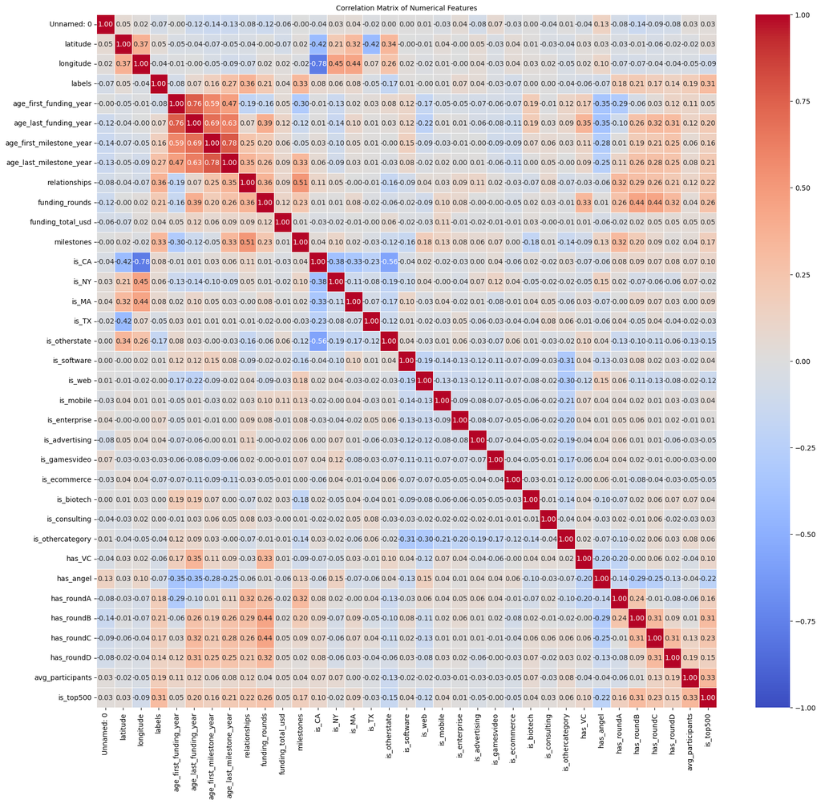

```python
# Compute and visualize the correlation matrix for numeric columns

# Select numerical columns from the dataset
numerical_columns = df.select_dtypes(include=['number']).columns

# Computing the correlation matrix
correlation_matrix = df[numerical_columns].corr()

# Ploting matrix
plt.figure(figsize=(20, 18))
sns.heatmap(correlation_matrix, annot=True, cmap='coolwarm', fmt='.2f', linewidths=0.5, vmin=-1, vmax=1)
plt.title("Correlation Matrix of Numerical Features", fontsize=10)
plt.show()
```

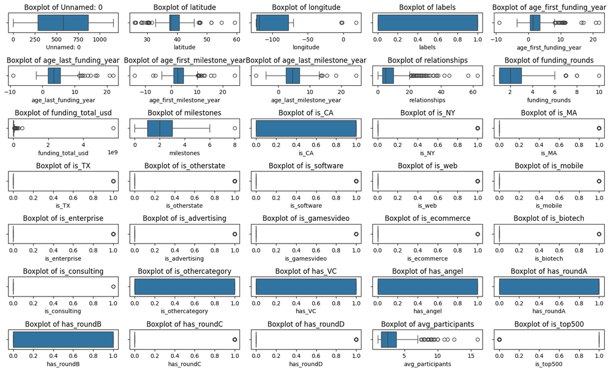

```python
# Visualize the outliers in the numerical columns
plt.figure(figsize=(15, 10))
for i, col in enumerate(numerical_columns, 1):
    plt.subplot(8, 5, i)
    sns.boxplot(x=df[col])
    plt.title(f"Boxplot of {col}")
plt.tight_layout()
plt.show()
```

```python
# Displaying summary statistics for categorical values in the dataset
print("\nCategorical Statics:\n")
categorical_summary = df.describe(include=['object'])
display(categorical_summary)
```

```
Categorical Statics:
```

|  | state_code | zip_code | id | city | Unnamed: 6 | name | founded_at | closed_at | first_funding_at | last_funding_at | state_code.1 | category_code | object_id | status |
| --- | --- | --- | --- | --- | --- | --- | --- | --- | --- | --- | --- | --- | --- | --- |
| count | 923 | 923 | 923 | 923 | 430 | 923 | 923 | 335 | 923 | 923 | 922 | 923 | 923 | 923 |
| unique | 35 | 382 | 922 | 221 | 252 | 922 | 217 | 202 | 585 | 680 | 35 | 35 | 922 | 2 |
| top | CA | 94107 | c:28482 | San Francisco | San Francisco CA 94105 | Redwood Systems | 1/1/2003 | 6/1/2013 | 1/1/2008 | 1/1/2008 | CA | software | c:28482 | acquired |
| freq | 488 | 30 | 2 | 128 | 12 | 2 | 55 | 25 | 18 | 11 | 487 | 153 | 2 | 597 |

```python
# Checking the class distribution to be sure that the model works even though it does not have a large number of records.
df['status'].value_counts(normalize=True)
```

```
status
acquired    0.646804
closed      0.353196
Name: proportion, dtype: float64
```

[figure not shown]

```python
# Plot target column
plt.figure(figsize=(6, 4))
sns.countplot(data=df, x='status', order=df['status'].value_counts().index)
plt.title("Distribution of Status")
plt.xticks(rotation=45, ha='right')
plt.show()
```

```python
# Checking for duplicates
duplicate_rows = df[df.duplicated()]
print(f"Number of duplicate rows: {duplicate_rows.shape[0]}")
```

```
Number of duplicate rows: 0
```

## Data exploration analysis

The first step for the exploration of the data is the loading of the dataset, with this sample of the data is reviewed and rectified that the structure and values were reasonable, then I obtained the shape that gave me 923 records and 49 columns, it is a small dataset but big enough to work with it considering that the objective is to build a prediction model.

Then when reviewing the information in the dataset there are different types of categorical and numerical columns, most of the columns are well defined but there are some problems that need to be addressed.

[output not shown]

A review of the statistics of the categorical columns is also performed to get an overview of the distribution of these, no strange values are found other than the partial unbalance of our target column “status” since it has a significant number of “acquired” values but also of “closed”. The “category_code” column is considered duplicated since it refers to categories that are numerically classified.

The status variable is analyzed in depth, to make sure that the model can learn correctly and although it presents a slight unbalance, the values of acquired (64.7%) and closed (35.3%) still work for our model, but perhaps if the performance is affected it may require a balancing, a graph of the variable can also be visualized.

Finally it is rectified that the dataset will not have duplicate records, when the rectification is executed we are guaranteed that each record corresponds to a different startup.

## Data preprocessing and feature engineering

```python
# Elimination of discarded, duplicate and columns related to the explicit location of the United States.
columns_to_drop=['age_first_funding_year','age_first_milestone_year', 'Unnamed: 0', 'Unnamed: 6', 'is_CA', 'is_NY', 'is_MA', 'is_TX','is_otherstate', 'state_code', 'state_code.1', 'latitude', 'longitude', 'zip_code', 'city','category_code','object_id', 'id','name','labels']
df = df.drop(columns=columns_to_drop)
```

```python
#Those startups that have not reached a milestone are assigned a value of zero.
df['age_last_milestone_year'] = df['age_last_milestone_year'].fillna(0)
```

```python
#Removing datetime columns
df = df.drop(columns=['founded_at', 'closed_at', 'first_funding_at', 'last_funding_at'])
display(df.columns)
```

```
Index(['age_last_funding_year', 'age_last_milestone_year', 'relationships',
       'funding_rounds', 'funding_total_usd', 'milestones', 'is_software',
       'is_web', 'is_mobile', 'is_enterprise', 'is_advertising',
       'is_gamesvideo', 'is_ecommerce', 'is_biotech', 'is_consulting',
       'is_othercategory', 'has_VC', 'has_angel', 'has_roundA', 'has_roundB',
       'has_roundC', 'has_roundD', 'avg_participants', 'is_top500', 'status'],
      dtype='object')
```

```python
# Conversion from categorical to numerical variables
df['status'] = df['status'].map({'acquired': 1, 'closed': 0})
```

```python
#Normalization of numerical variables
from sklearn.preprocessing import StandardScaler

cols_to_normalize = ['age_last_funding_year','age_last_milestone_year', 'relationships', 'funding_rounds', 'funding_total_usd',
                     'milestones', 'avg_participants']

scaler = StandardScaler()
df[cols_to_normalize] = scaler.fit_transform(df[cols_to_normalize])
print(df[cols_to_normalize].head())
```

```
   age_last_funding_year  age_last_milestone_year  relationships  \
0              -0.313102                 0.798320      -0.648696
1               2.044918                 0.886371       0.177541
2              -0.977162                -0.515913      -0.373284
3               0.466454                 0.593411      -0.373284
4              -0.762888                -1.149015      -0.786402

   funding_rounds  funding_total_usd  milestones  avg_participants
0        0.495665          -0.132140    0.876138         -0.981320
1        1.215002           0.077455   -0.636819          1.020191
2       -0.943010          -0.120401    0.119660          0.619888
3        0.495665           0.076928   -0.636819          0.264047
4       -0.223673          -0.127260   -0.636819         -0.981320
```

```python
#Split the information into test and training
from sklearn.model_selection import train_test_split
from sklearn.impute import SimpleImputer
from sklearn.preprocessing import StandardScaler

X = df.drop(columns=['status'])  # Features
y = df['status']  # Target

X_train, X_test, y_train, y_test = train_test_split(X, y, test_size=0.2, random_state=42, stratify=y)


# Apply imputer to the training features (X_train) to fill NaNs
imputer = SimpleImputer(strategy='mean')
X_train_imputed = imputer.fit_transform(X_train)
X_test_imputed = imputer.transform(X_test)


# Scaling of all numeric columns
scaler = StandardScaler()
X_train_scaled = scaler.fit_transform(X_train_imputed)
X_test_scaled = scaler.transform(X_test_imputed)
```

## Data preprocessing and features engineering analysis

As a first step we eliminated the characteristics that were discarded by the conditions explained in the previous point, in addition to that we eliminated two characteristics not mentioned before “age_first_funding_year” and “age_first_milestone_year”, since they had a very high correlation with “age_last_funding_year” and “age_last_milestone_year” respectively and at the time of cross validation with the models did not converge, so it was decided to eliminate the first ones and leave the last ones since their high correlation provided similar information to the model.

The fields of the variables that had null values are filled in, in the case of “age_last_milestone_year” the empty values are filled with zeros. The columns related to the dates are removed since they were not providing important information and were also generating problems at the time of doing the cross validations since for example the linear regression model could not converge with these values.

The target characteristic is converted from categorical to numerical to be able to work with the training step of the model and the variables are normalized with different scales so that the model can work better with them.

Finally, dataset is divided into subsets for training and testing, an imputation must be applied to the training and testing set to fill the values that have NaN with a value that is in the mean of these characteristics and a standardization must be applied again since the algorithms were not converging for some reason, as if any of the variables had scales that could not work, the two standardizations are left as evidence of the process carried out in the report.

## Model training

### Select best machine learning algorithm

```python
#Logistic Regression
from sklearn.linear_model import LogisticRegression
from sklearn.model_selection import GridSearchCV

# Define the model
logreg = LogisticRegression(solver='saga', max_iter=1000)

# Evaluate using cross-validation
logreg_score = cross_val_score(logreg, X_train_scaled, y_train, cv=5, scoring='accuracy')
print("Logistic Regression Mean Accuracy: ", logreg_score.mean())
```

```
Logistic Regression Mean Accuracy:  0.7520408163265306
```

```python
#Naive Bayes
from sklearn.naive_bayes import GaussianNB
from sklearn.model_selection import cross_val_score

# Define the model
nb = GaussianNB()

# Evaluate using cross-validation
nb_score = cross_val_score(nb, X_train_scaled, y_train, cv=5, scoring='accuracy')
print("Naive Bayes Mean Accuracy: ", nb_score.mean())
```

```
Naive Bayes Mean Accuracy:  0.6112061040632468
```

```python
#Support vector machine
from sklearn.svm import SVC

# Define the model
svm = SVC()

# Evaluate using cross-validation
svm_score = cross_val_score(svm, X_train_scaled, y_train, cv=5, scoring='accuracy')
print("SVM Mean Accuracy: ", svm_score.mean())
```

```
SVM Mean Accuracy:  0.7615278543849973
```

```python
#K-Nearest Neighbors
from sklearn.neighbors import KNeighborsClassifier


# Define the model
knn = KNeighborsClassifier()

# Evaluate using cross-validation
knn_score = cross_val_score(knn, X_train_scaled, y_train, cv=5, scoring='accuracy')
print("KNN Mean Accuracy: ", knn_score.mean())
```

```
KNN Mean Accuracy:  0.6951553594410737
```

```python
#Decision Trees
from sklearn.tree import DecisionTreeClassifier


# Define the model
dt = DecisionTreeClassifier()

# Evaluate using cross-validation
dt_score = cross_val_score(dt, X_train_scaled, y_train, cv=5, scoring='accuracy')
print("Decision Tree Mean Accuracy: ", dt_score.mean())
```

```
Decision Tree Mean Accuracy:  0.7086964515535945
```

```python
#Random Forest
from sklearn.ensemble import RandomForestClassifier


# Define the model
rf = RandomForestClassifier()

# Evaluate using cross-validation
rf_score = cross_val_score(rf, X_train_scaled, y_train, cv=5, scoring='accuracy')
print("Random Forest Mean Accuracy : ", rf_score.mean())
```

```
Random Forest Mean Accuracy :  0.7885916528773671
```

```
LogisticRegression(C=0.1, max_iter=1000, solver='saga')
Accuracy: 0.7351351351351352
Report:
              precision    recall  f1-score   support

           0       0.62      0.65      0.63        65
           1       0.80      0.78      0.79       120

    accuracy                           0.74       185
   macro avg       0.71      0.71      0.71       185
weighted avg       0.74      0.74      0.74       185
```

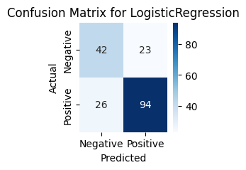

```
GaussianNB()
Accuracy: 0.6216216216216216
Report:
              precision    recall  f1-score   support

           0       0.48      0.83      0.61        65
           1       0.85      0.51      0.64       120

    accuracy                           0.62       185
   macro avg       0.66      0.67      0.62       185
weighted avg       0.72      0.62      0.63       185
```

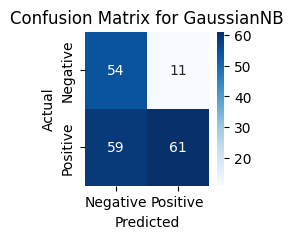

```
SVC(C=0.1, kernel='linear')
Accuracy: 0.745945945945946
Report:
              precision    recall  f1-score   support

           0       0.64      0.65      0.64        65
           1       0.81      0.80      0.80       120

    accuracy                           0.75       185
   macro avg       0.72      0.72      0.72       185
weighted avg       0.75      0.75      0.75       185
```

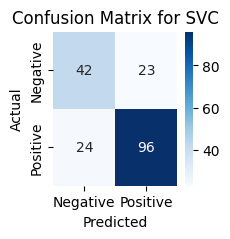

```
KNeighborsClassifier(n_neighbors=9)
Accuracy: 0.7189189189189189
Report:
              precision    recall  f1-score   support

           0       0.62      0.51      0.56        65
           1       0.76      0.83      0.79       120

    accuracy                           0.72       185
   macro avg       0.69      0.67      0.68       185
weighted avg       0.71      0.72      0.71       185
```

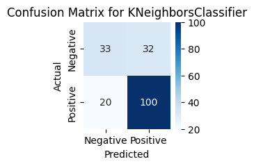

```
DecisionTreeClassifier(max_depth=3)
Accuracy: 0.8054054054054054
Report:
              precision    recall  f1-score   support

           0       0.80      0.60      0.68        65
           1       0.81      0.92      0.86       120

    accuracy                           0.81       185
   macro avg       0.80      0.76      0.77       185
weighted avg       0.80      0.81      0.80       185
```

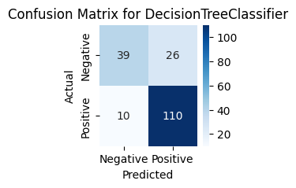

[output not shown]

[figure not shown]

```python
#Performance evaluation
from sklearn.metrics import accuracy_score, confusion_matrix, classification_report, roc_curve, auc

# Function for evaluation of the models and generate performance metrics
def evaluate_model(model, X_test, y_test):
    y_pred = model.predict(X_test)
    accuracy = accuracy_score(y_test, y_pred)
    conf_matrix = confusion_matrix(y_test, y_pred)
    report = classification_report(y_test, y_pred)

    # Print metrics
    print(model)
    print(f"Accuracy: {accuracy}")
    print(f"Report:\n{report}")

    # Confusion Matrix Visualization
    plt.figure(figsize=(2,2))
    sns.heatmap(conf_matrix, annot=True, fmt='d', cmap='Blues', xticklabels=['Negative', 'Positive'], yticklabels=['Negative', 'Positive'])
    plt.title(f"Confusion Matrix for {model.__class__.__name__}")
    plt.xlabel('Predicted')
    plt.ylabel('Actual')
    plt.show()

# Evaluate each model

evaluate_model(grid_search_logreg.best_estimator_, X_test_scaled, y_test)

nb.fit(X_train_scaled, y_train)
evaluate_model(nb, X_test_scaled, y_test)

evaluate_model(grid_search_svm.best_estimator_, X_test_scaled, y_test)

evaluate_model(grid_search_knn.best_estimator_, X_test_scaled, y_test)

evaluate_model(grid_search_dt.best_estimator_, X_test_scaled, y_test)

evaluate_model(grid_search_rf.best_estimator_, X_test_scaled, y_test)
```

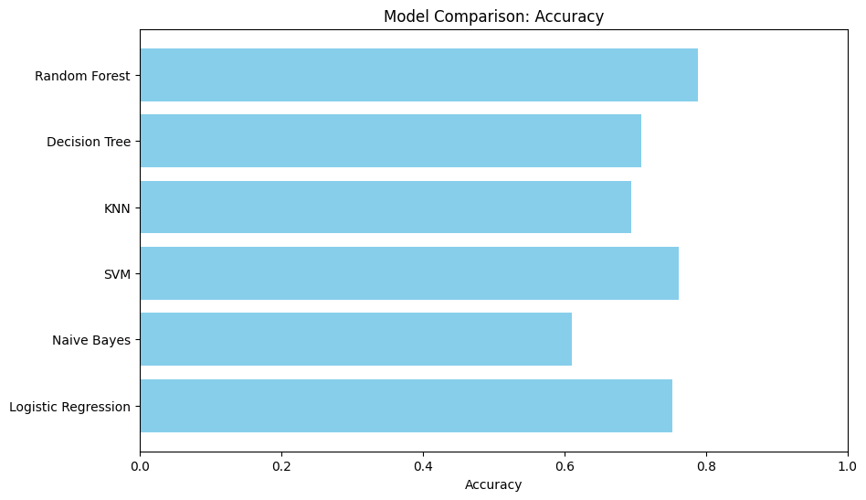

```python
#Model comparison
models = ['Logistic Regression', 'Naive Bayes', 'SVM', 'KNN', 'Decision Tree', 'Random Forest']
accuracies = [logreg_score.mean(), nb_score.mean(), svm_score.mean(), knn_score.mean(), dt_score.mean(), rf_score.mean()]


plt.figure(figsize=(10,6))
plt.barh(models, accuracies, color='skyblue')
plt.xlabel('Accuracy')
plt.title('Model Comparison: Accuracy')
plt.xlim([0, 1])
plt.show()
```

## Select best machine learning algorithm analysis

Linear Regression, Naive Bayes, Suppor Vector Machine, K-Nearest Neighboors, Decision trees and Random Forest models are applied, each one of them is evaluated using cross validation that divides the data in subsets, trains the model in some of these subsets and tests them in the remaining ones, repeats the process several times and helps us to evaluate the performance in a more reliable way, this gave us an average of precision for each one of the models in which the best result was for Random Forest with an average of precision of 0.7885.

Then a function is performed to evaluate the models with a more information function is used to calculate the accuracy of the model, a confusion matrix and the classification report, with these can be given the following statements

[output not shown]

Finally, a comparison of the different model accuracy results can be visualized with the cross validation method, which was crucial in making the decision to go with Random Forest.

## Random Forest Assesment

```python
#Training the model
rf = RandomForestClassifier(random_state=42)
rf.fit(X_train_scaled, y_train)

#Prediction
y_pred = rf.predict(X_test_scaled)

#Evaluation
accuracy = accuracy_score(y_test, y_pred)
print(f"Random Forest Accuracy (Without tuning): {accuracy:.4f}")
```

```
Random Forest Accuracy (Without tuning): 0.7784
```

```python
#Hyperparameter tuning

#Hyperparameters to test
param_grid = {
    'n_estimators': [50, 100, 200],
    'max_depth': [5, 10, None],
    'min_samples_split': [2, 5, 10],
    'min_samples_leaf': [1, 2, 4]
}

#Apply grid search with cross validation
grid_search_rf = GridSearchCV(rf, param_grid, cv=5, scoring='accuracy', n_jobs=-1)
grid_search_rf.fit(X_train_scaled, y_train)

print("Best Parameters:", grid_search_rf.best_params_)

#Evaluate model with best parameters
best_rf = grid_search_rf.best_estimator_
y_pred_best = best_rf.predict(X_test_scaled)

accuracy_best = accuracy_score(y_test, y_pred_best)
print(f"Tuned Random Forest Accuracy: {accuracy_best:.4f}")
```

```
Best Parameters: {'max_depth': None, 'min_samples_leaf': 1, 'min_samples_split': 5, 'n_estimators': 100}
Tuned Random Forest Accuracy: 0.8054
```

```
Report:
              precision    recall  f1-score   support

           0       0.77      0.63      0.69        65
           1       0.82      0.90      0.86       120

    accuracy                           0.81       185
   macro avg       0.80      0.77      0.78       185
weighted avg       0.80      0.81      0.80       185
```

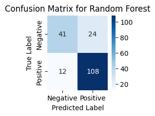

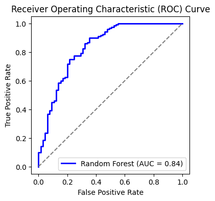

```python
#Report
report = classification_report(y_test, y_pred_best)
print(f"Report:\n{report}")

# Generate confusion matrix
conf_matrix = confusion_matrix(y_test, y_pred_best)

# Plot confusion matrix
plt.figure(figsize=(2,2))
sns.heatmap(conf_matrix, annot=True, fmt='d', cmap='Blues', xticklabels=['Negative', 'Positive'], yticklabels=['Negative', 'Positive'])
plt.title("Confusion Matrix for Random Forest")
plt.xlabel('Predicted Label')
plt.ylabel('True Label')
plt.show()

# Get predicted probabilities
y_prob = best_rf.predict_proba(X_test_scaled)[:,1]

# Compute ROC curve and AUC score
fpr, tpr, _ = roc_curve(y_test, y_prob)
roc_auc = auc(fpr, tpr)

# Plot ROC curve
plt.figure(figsize=(4,4))
plt.plot(fpr, tpr, color='blue', lw=2, label=f'Random Forest (AUC = {roc_auc:.2f})')
plt.plot([0, 1], [0, 1], color='gray', linestyle='--')
plt.title('Receiver Operating Characteristic (ROC) Curve')
plt.xlabel('False Positive Rate')
plt.ylabel('True Positive Rate')
plt.legend(loc='lower right')
plt.show()
```

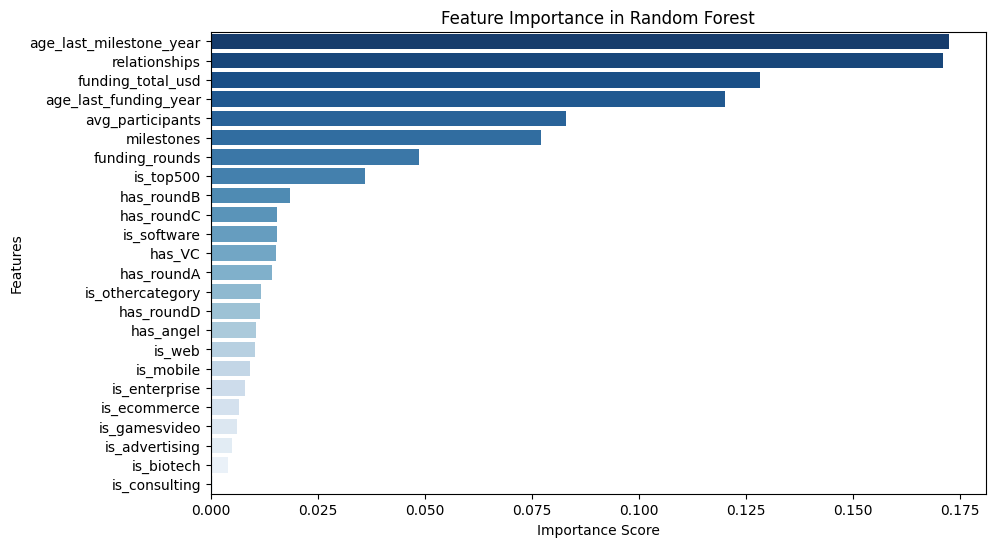

```python
import numpy as np

# Feature importance
feature_importance = best_rf.feature_importances_

# Sort
sorted_idx = np.argsort(feature_importance)[::-1]
sorted_features = X.columns[sorted_idx]

# Plot
plt.figure(figsize=(10,6))
sns.barplot(x=feature_importance[sorted_idx], y=sorted_features, palette="Blues_r", hue=sorted_features, legend=False)
plt.title("Feature Importance in Random Forest")
plt.xlabel("Importance Score")
plt.ylabel("Features")
plt.show()
```

## Random Forest Assesment analysis

First of all, the model is trained with the data and a prediction of the target is made with which an evaluation is made that gives us a result of 0.7784 of average accuracy, which is not bad but we will try to improve it with the next step.

We start the tuning of hyperparameters selecting 4 of them n_estimators, max_depth, min_samples_split and min_samples_leaf, we assign them different common values and through grid search with cross validation that will test all possible combinations of the values that we defined, after that gives us as a result the best values for these parameters, they are applied and we proceed to evaluate the model in this way, it gives us an accuracy of 0. 8054, which represents a circumstantial improvement that in business terms translates into better decision making.

Now the model is evaluated with a classification report, confusion matrix, ROC curve and AUC score, leaving the following insights

[output not shown]

As a final step, the most important features for the model are graphed, which will be discussed in more detail later.

## Final discussion

Talking about the strengths of the project, a comprehensive pipeline has been developed, which addresses the proposed problem in the right way, starting with the exploration of the data, identifying what type of information is available, preprocessing the data, evaluating the different models in order to select the best, train it, run a tuning of hyperparameters and gives us as a result an improvement in accuracy, then an evaluation of the results is performed. After the process, the following points can be highlighted:

```
By running a diverse evaluation of the different machine learning algorithms it can be assured that enough approaches were explored to solve the problem that ultimately led to selecting the most accurate model for this case.

With the best model selected, Random forest, which gave us the best performance results, a tuning process for the hyperparameters was performed which allowed an improvement in the accuracy, improving the overall performance of the model.

The model also gave us clarity on the most important features within the dataset that are of vital importance as they serve as a guide for the following business decisions and improvements to the model.
```

About limitations, in spite of achieving a great model that, based on the type of problem we are dealing with, gives us a good result with an accuracy of 0.8, the following limitations can be mentioned within the project:

```
In principle, the size and complexity of the dataset presented certain problems when making the model, despite having variables that contributed a lot to the problem, it was not a perfect dataset; with a larger and better constructed dataset, better results would surely be obtained.

The complexity of the selected model could mean problems later on, since Random Forest, despite being a powerful algorithm, is computationally expensive, which could limit the efficiency of the model.
```

For the business the results are positive, the model achieved an accuracy of 0.8054 which has important implications, the model can be used to make decisions based on real information, we can continue to feed the model and increase its accuracy, which will result in an increasingly robust model that will avoid capital losses and help identify new startups with great potential, which translates into more money for our organization, thus solving the proposed problem and adding great value to the organization through the development of this project.

Based on the information and results obtained, the following recommendations could be made to the business for the continuous improvement of the project in general:

```
We should focus on the most important features identified by the Random Forest model, these will be crucial in the process of predicting success or failure for new startups that are presented for investment in our organization, the most important features were the following:

    “age_last_milestone_year”
    “relationships”
    “funding_total_usd”
    “age_last_funding_year”
    “avg_participants”
    “milestones”
    “funding_rounds”
    “is_top500”

A simplification of the model could be applied sacrificing a little accuracy if faster predictions are required, i.e. another model such as logistic regression could be chosen to make faster predictions.
```

In terms of explainability, Random Forest despite being a great model does not have an easy explainability, it brings us great value with the most important features but it is a bit complex to understand which features are really influential in the project because you can not easily interpret the relationship of these with the result, you could apply techniques such as Shapley Additive Explanations to Random Forest that could generate a more transparent process and improve the decision making of the model.

### References

Maksi, Y. (2023). Big Startup Success & Fail Dataset from Crunchbase [Data set]. Kaggle. https://www.kaggle.com/datasets/yanmaksi/big-startup-secsees-fail-dataset-from-crunchbase